# Statistical inference with the GSS data

**Research quesion 2:**

```r
# Frequency table based on smoking behavior
table(data$smoking, useNA = "always")/nrow(data)
```

```
##
##        Yes         No       <NA>
## 0.43760053 0.53206039 0.03033908
```

```r
# Frequency table based on exercise activity
table(data$exercise, useNA = "always")/nrow(data)
```

```
##
##        Yes         No       <NA>
## 0.67604901 0.25475472 0.06919628
```

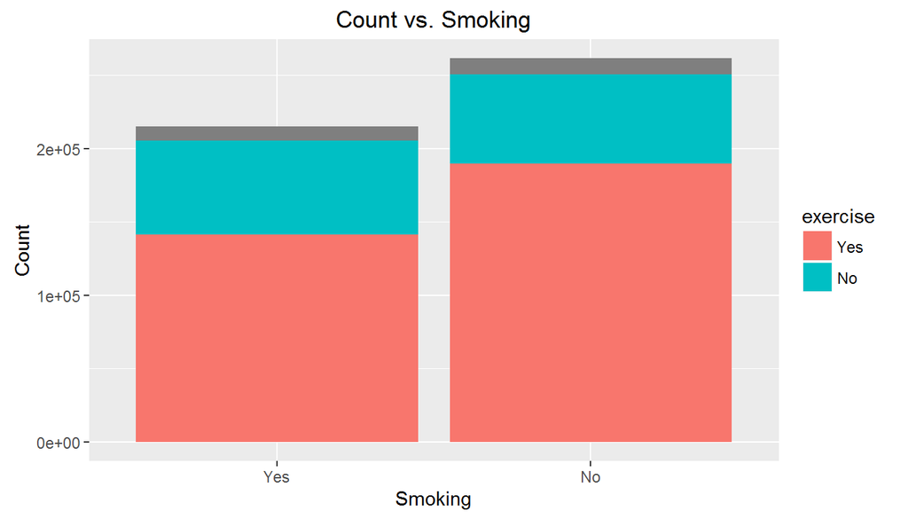

```r
ggplot(data[!is.na(data$smoking), ], aes(smoking)) +
     geom_bar(aes(fill = exercise)) +
     labs(title = "Count vs. Smoking") +
     xlab("Smoking") +
     ylab("Count")
```

Graph Interpretation :  
About 44 percent of people are smoking.  
About 67 percent of people are doing exercise activity.  
Non-smoker tends to exercise more than smoker.

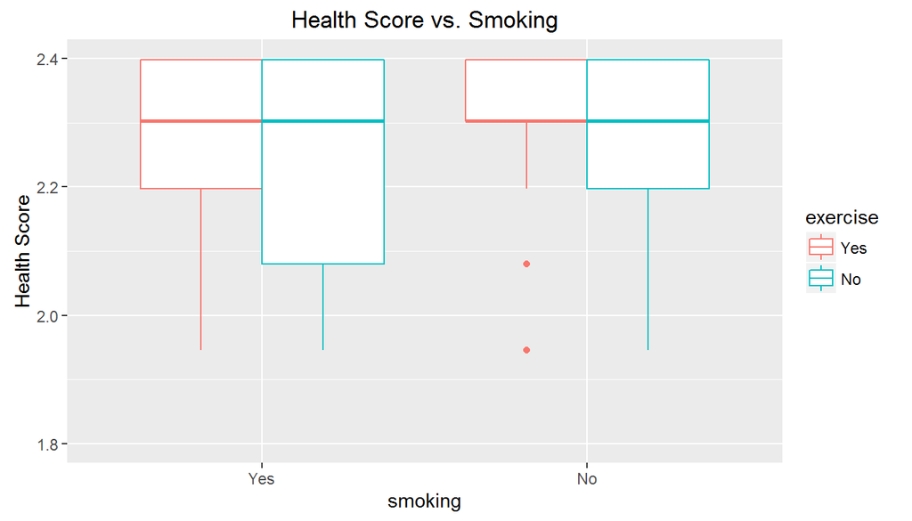

```r
ggplot(data[!is.na(data$smoking) & !is.na(data$exercise), ], aes(smoking, healthScore)) +
     geom_boxplot(aes(colour = exercise)) +
     ylim(1.8, 2.4) +
     labs(title = "Health Score vs. Smoking") +
     xlab("smoking") +
     ylab("Health Score")
```

Graph Interpretation :  
Non-smoker and exercising group tends to have very steady high health score; wheres smoker and non-exercising have very high variance in health score.  
Based on the boxplot, smoking and health score are linearly dependent and exercising and health score are linearly dependent.

### Conclusion :

Non-smoker and exercising group variable both positively impacting on health score.

**Research quesion 3:**

```r
# Frequency table based on sleeping hours
summary(as.numeric(data[!is.na(data$sleepingHour),]$sleepingHour))
```

```
##    Min. 1st Qu.  Median    Mean 3rd Qu.    Max.
##   0.000   6.000   7.000   7.052   8.000 450.000
```

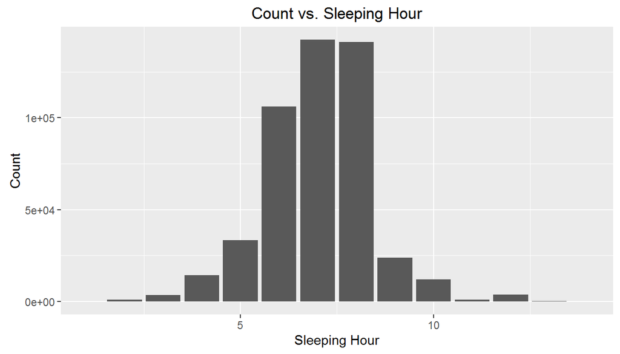

```r
ggplot(data[!is.na(data$sleepingHour), ], aes(sleepingHour)) +
     geom_bar() +
     xlim(1, 14) +
     labs(title = "Count vs. Sleeping Hour") +
     xlab("Sleeping Hour") +
     ylab("Count")
```

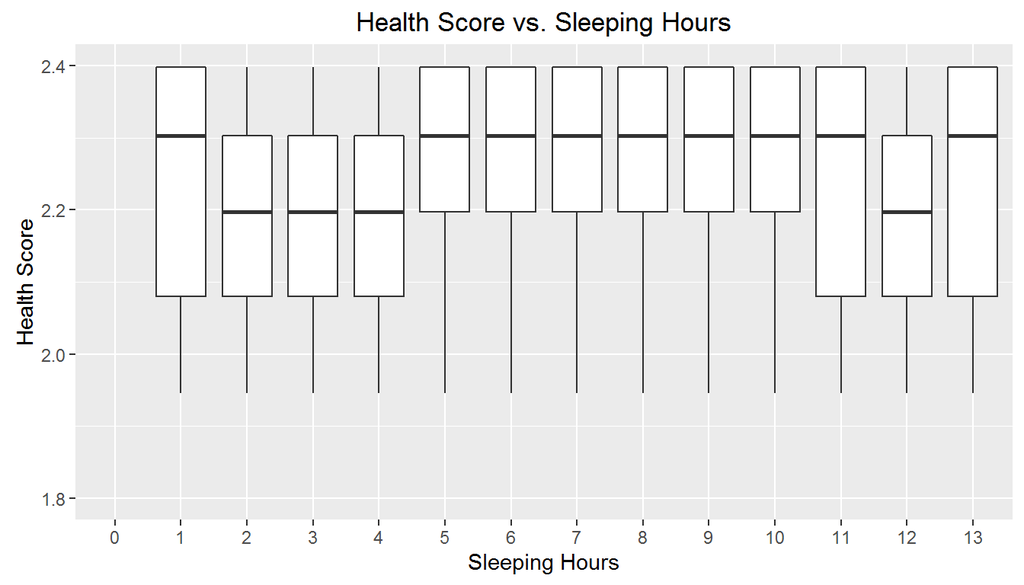

```r
data$sleepingHour <- as.factor(data$sleepingHour)
ggplot(data[!is.na(data$sleepingHour) & as.numeric(data$sleepingHour) >= 1 & as.numeric(data$sleepingHour) <= 14, ], aes(sleepingHour, healthScore)) +
     geom_boxplot() +
     ylim(1.8, 2.4) +
     labs(title = "Health Score vs. Sleeping Hours") +
     xlab("Sleeping Hours") +
     ylab("Health Score")
```

Graph Interpretation :  
Box chart implies that there is no dependent association between ‘sleeping hours’ and ‘health score’.

### Conclusion :

‘sleeping hours’ and ‘health score’ are independent to each other.

## Part 4: Inference

```r
# Remove dirty values
data <- data[!is.infinite(data$healthScore), ]
data <- data[!is.na(data$healthCare), ]
data <- data[!is.na(data$smoking), ]
data <- data[!is.na(data$exercise), ]
data <- data[!is.na(data$sleepingHour), ]
data <- data[!is.na(data$income), ]

data %>%
  summarise(mu = mean(healthScore), pop_med = median(healthScore),
            sigma = sd(healthScore), pop_iqr = IQR(healthScore),
            pop_min = min(healthScore), pop_max = max(healthScore),
            pop_q1 = quantile(healthScore, 0.25),  # first quartile, 25th percentile
            pop_q3 = quantile(healthScore, 0.75))  # third quartile, 75th percentile
```

```
##         mu  pop_med     sigma   pop_iqr pop_min  pop_max   pop_q1   pop_q3
## 1 2.260739 2.302585 0.1783177 0.2006707       0 2.397895 2.197225 2.397895
```

### True Population Mean and Confidence Interval

```r
# true population mean
params <- data %>%
     summarise(mu = mean(healthScore))

z_star_95 <- qnorm(0.975)
n <- nrow(data)
data %>%
  summarise(lower = mean(healthScore) - z_star_95 * (sd(healthScore) / sqrt(n)),
            upper = mean(healthScore) + z_star_95 * (sd(healthScore) / sqrt(n)))
```

[output not shown]

### Checking the skewness of the health score distribution

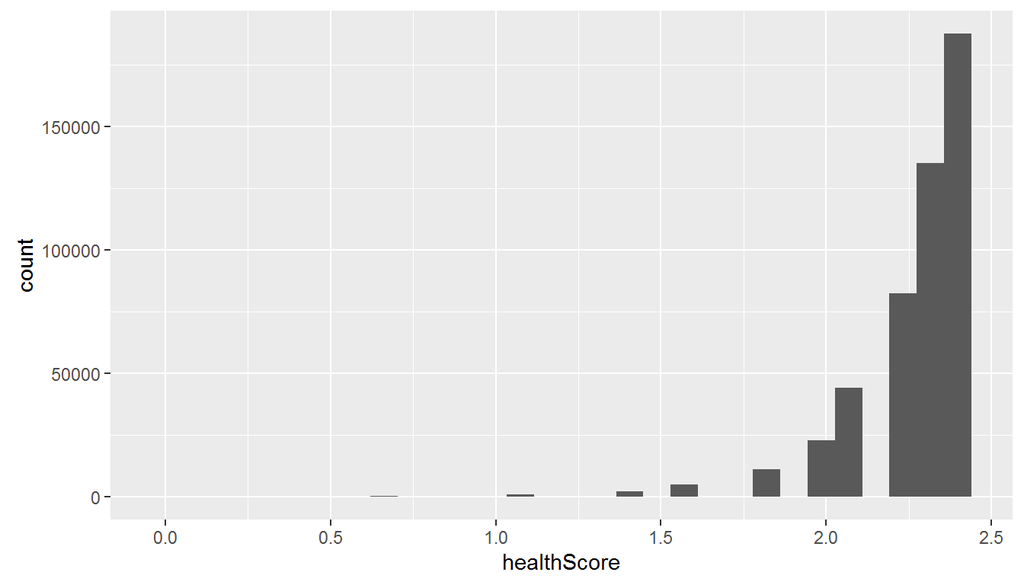

```r
# Checking the skewness
ggplot(data = data, aes(x = healthScore)) +
  geom_histogram()
```

### Apply Sampling Distribution

```
 We have to remove the skewness in order to make CLT to kick in.
 We will use sample size of 50 and 15000 samples with replacement.
```

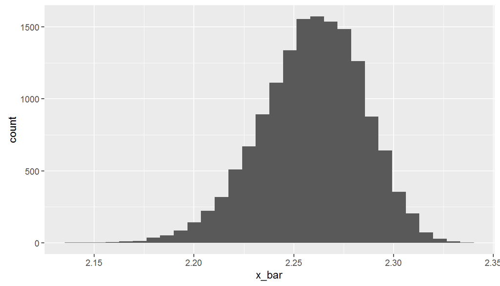

```r
sample_means50 <- data %>%
                    rep_sample_n(size = 50, reps = 15000, replace = TRUE) %>%
                    summarise(x_bar = mean(healthScore))

ggplot(data = sample_means50, aes(x = x_bar)) +
  geom_histogram()
```

### Building 95% Confidence Interval with Sampling Distribution

```r
z_star_95 <- qnorm(0.975)
z_star_95
```

```
## [1] 1.959964
```

```r
n <- 60
ci <- data %>%
     rep_sample_n(size = 60, reps = 50, replace = TRUE) %>%
     summarise(lower = mean(healthScore) - z_star_95 * (sd(healthScore) / sqrt(n)),
               upper = mean(healthScore) + z_star_95 * (sd(healthScore) / sqrt(n)))
ci %>%
  slice(1:5)
```

```
## Source: local data frame [5 x 3]
##
##   replicate    lower    upper
##       (int)    (dbl)    (dbl)
## 1         1 2.223796 2.301814
## 2         2 2.234782 2.312231
## 3         3 2.233199 2.308130
## 4         4 2.162791 2.283389
## 5         5 2.223725 2.306489
```

### Plotting Confidence Interval

```r
inference(y = healthScore, data = data, statistic = "mean", type = "ci",
          conf_level = 0.95, method = "theoretical", order = c("Yes","No"))
```

```
## Single numerical variable
## n = 389480, y-bar = 2.2607, s = 0.1783
## 95% CI: (2.2602 , 2.2613)
```

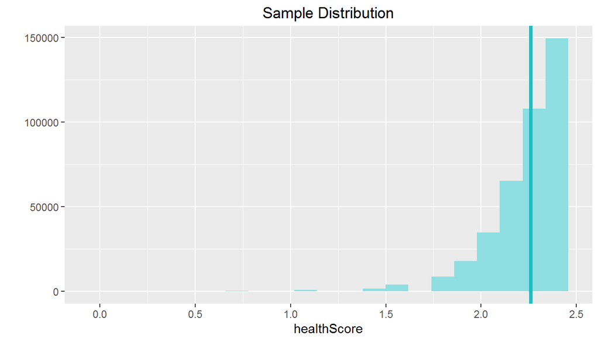

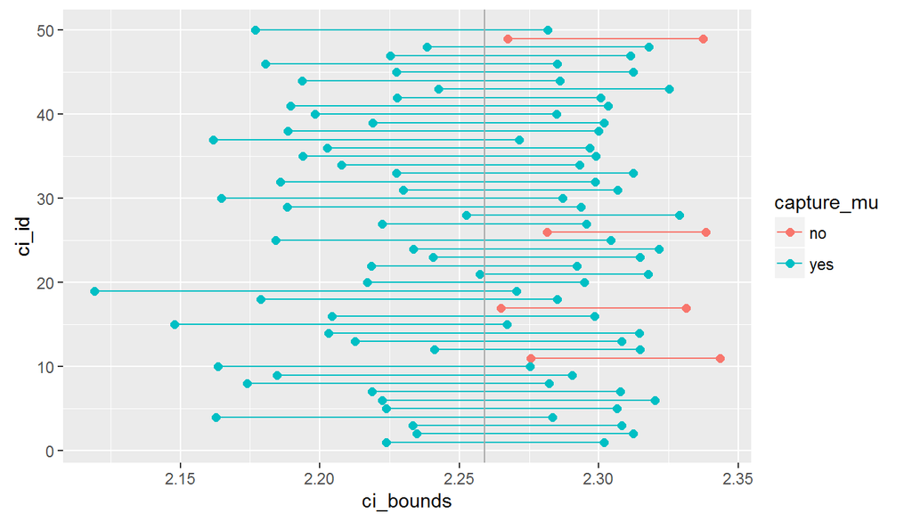

```r
ci <- ci %>%
     mutate(capture_mu = ifelse(lower < params$mu & upper > params$mu, "yes", "no"))

ci_data <- data.frame(ci_id = c(1:50, 1:50),
                      ci_bounds = c(ci$lower, ci$upper),
                      capture_mu = c(ci$capture, ci$capture))

ggplot(data = ci_data, aes(x = ci_bounds, y = ci_id, group = ci_id, color = capture_mu)) +
     geom_point(size = 2) +  # add points at the ends, size = 2
     geom_line() +           # connect with lines
     geom_vline(xintercept = params$mu, color = "darkgray") # draw vertical line
```

### Health Score vs Health Care.

$H_0: \mu_{health care} = \mu_{no health care}$; $H_A: \mu_{health care} \ne \mu_{no health care}$

```r
# Confidence Interval with function (Mean : Catagorical vs Quantative)
inference(y = healthScore, x = healthCare, data = data, statistic = "mean", type = "ci",
          method = "theoretical", order = c("Yes","No"))
```

```
## Response variable: numerical, Explanatory variable: categorical (2 levels)
## n_Yes = 346455, y_bar_Yes = 2.2565, s_Yes = 0.1806
## n_No = 43025, y_bar_No = 2.2948, s_No = 0.1544
## 95% CI (Yes - No): (-0.0399 , -0.0367)
```

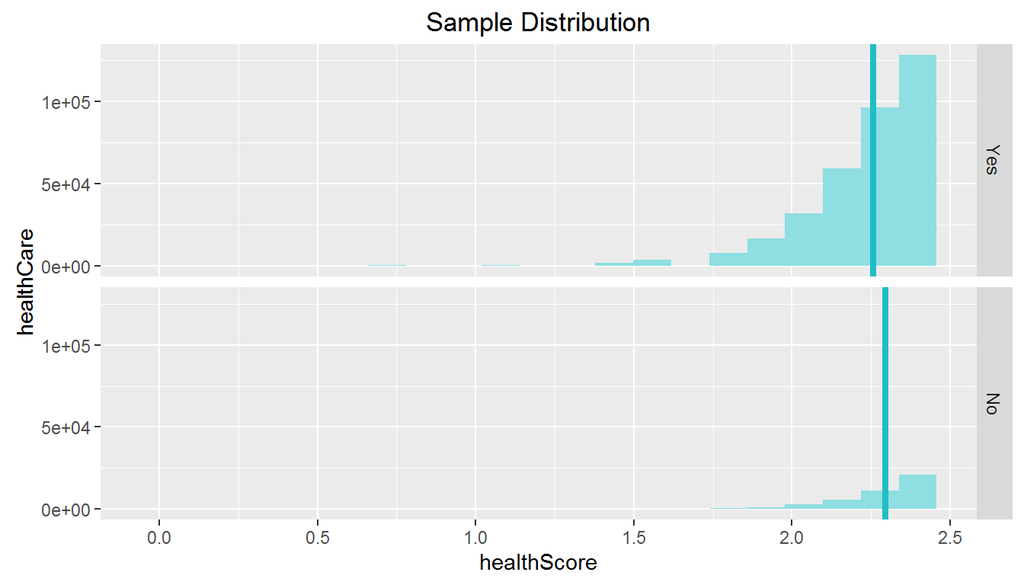

```r
# Hypothesis Test with functions (Mean : Catagorical vs Quantative)
inference(y = healthScore, x = healthCare, data = data, statistic = "mean", type = "ht", null = 0,
          alternative = "twosided", method = "theoretical")
```

```
## Response variable: numerical
## Explanatory variable: categorical (2 levels)
## n_Yes = 346455, y_bar_Yes = 2.2565, s_Yes = 0.1806
## n_No = 43025, y_bar_No = 2.2948, s_No = 0.1544
## H0: mu_Yes =  mu_No
## HA: mu_Yes != mu_No
## t = -47.5871, df = 43024
## p_value = < 0.0001
```

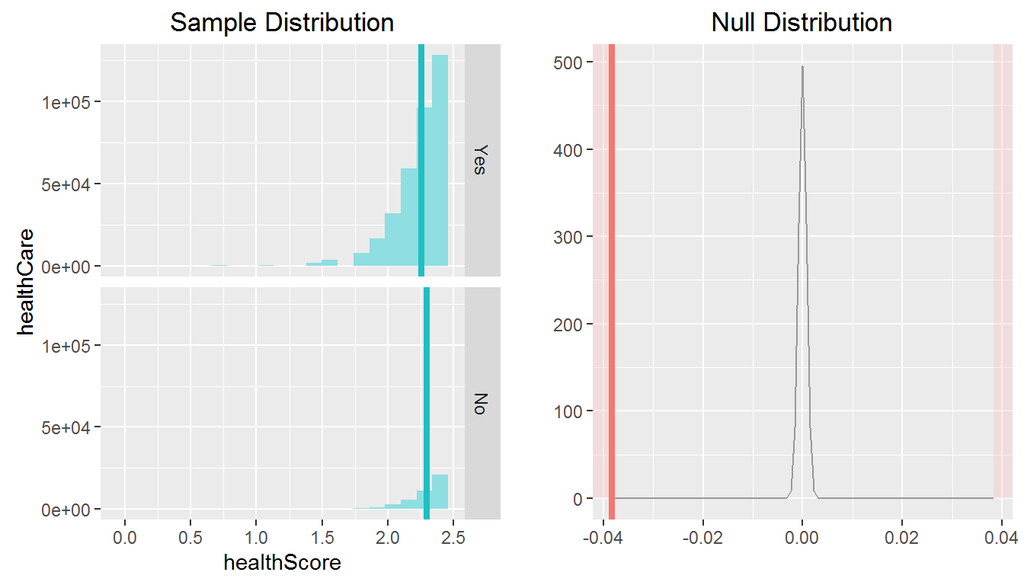

```r
s1 <- sd(data[data$healthCare == "Yes", ]$healthScore)
s2 <- sd(data[data$healthCare == "No", ]$healthScore)
n1 <- nrow(data[data$healthCare == "Yes", ])
n2 <- nrow(data[data$healthCare == "No", ])
x1 <- mean(data[data$healthCare == "Yes", ]$healthScore)
x2 <- mean(data[data$healthCare == "No", ]$healthScore)

# Confidence Interval with hand
x_diff <- x1 - x2
se <- sqrt((s1^2/n1) + (s2^2/n2))

z <- abs(qnorm(.025))  # 95%
ci <- round(c(x_diff - z*se, x_diff + z*se), 4)
ci
```

```
## [1] -0.0399 -0.0367
```

```r
# Hypothesis Test with hand
se <- sqrt((s1^2/n1) + (s2^2/n2))
t <- (x1 - x2) / se
df <- min(n1, n2) - 1
pt(t, df)
```

```
## [1] 0
```

**Interpretation**  
The population mean lies between these two bounds of -0.0399 -0.0367, since 95% of the time confidence intervals contain the true mean.  
Since the p-value is less than .05 we will reject the null hypothesis and accept the alternative hypothesis that Health care accessibility is effecting on Health Score.

### Health Score vs Smoking.

$H_0: \mu_{smoking} = \mu_{notSmoking}$; $H_A: \mu_{smoking} \ne \mu_{notSmoking}$

```r
# Confidence Interval with function (Mean : Catagorical vs Quantative)
inference(y = healthScore, x = smoking, data = data, statistic = "mean", type = "ci",
          method = "theoretical", order = c("Yes","No"))
```

```
## Response variable: numerical, Explanatory variable: categorical (2 levels)
## n_Yes = 177784, y_bar_Yes = 2.227, s_Yes = 0.2004
## n_No = 211696, y_bar_No = 2.2891, s_No = 0.1517
## 95% CI (Yes - No): (-0.0632 , -0.061)
```

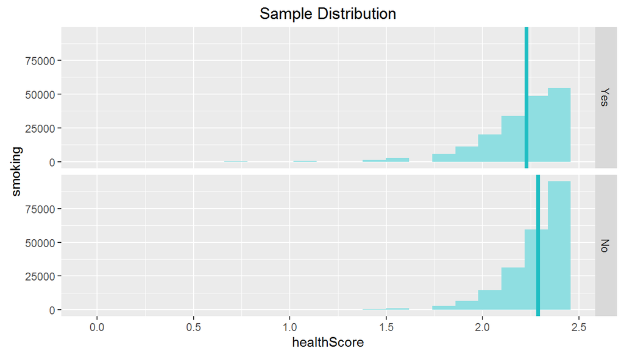

```r
# Hypothesis Test with functions (Mean : Catagorical vs Quantative)
inference(y = healthScore, x = smoking, data = data, statistic = "mean", type = "ht", null = 0,
          alternative = "twosided", method = "theoretical")
```

```
## Response variable: numerical
## Explanatory variable: categorical (2 levels)
## n_Yes = 177784, y_bar_Yes = 2.227, s_Yes = 0.2004
## n_No = 211696, y_bar_No = 2.2891, s_No = 0.1517
## H0: mu_Yes =  mu_No
## HA: mu_Yes != mu_No
## t = -107.3792, df = 177783
## p_value = < 0.0001
```

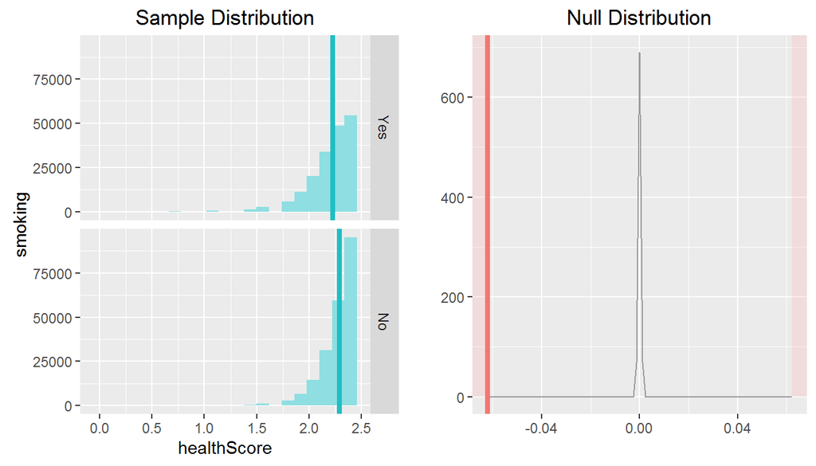

```r
s1 <- sd(data[data$smoking == "Yes", ]$healthScore)
s2 <- sd(data[data$smoking == "No", ]$healthScore)
n1 <- nrow(data[data$smoking == "Yes", ])
n2 <- nrow(data[data$smoking == "No", ])
x1 <- mean(data[data$smoking == "Yes", ]$healthScore)
x2 <- mean(data[data$smoking == "No", ]$healthScore)

# Confidence Interval with hand
x_diff <- x1 - x2
se <- sqrt((s1^2/n1) + (s2^2/n2))

z <- abs(qnorm(.025))  # 95%
ci <- round(c(x_diff - z*se, x_diff + z*se), 4)
ci
```

```
## [1] -0.0632 -0.0610
```

```r
# Hypothesis Test with hand
se <- sqrt((s1^2/n1) + (s2^2/n2))
t <- (x1 - x2) / se
df <- min(n1, n2) - 1
pt(t, df)
```

```
## [1] 0
```

**Interpretation**  
The population mean lies between these two bounds of -0.0632 -0.0610, since 95% of the time confidence intervals contain the true mean.  
Since the p-value is less than .05 we will reject the null hypothesis and accept the alternative hypothesis that smoking behavior is effecting on Health Score.

### Health Score vs Exercise.

```r
# Confidence Interval with function (Mean : Catagorical vs Quantative)
inference(y = healthScore, x = exercise, data = data, statistic = "mean", type = "ci",
          method = "theoretical", order = c("Yes","No"))
```

```
## Response variable: numerical, Explanatory variable: categorical (2 levels)
## n_Yes = 286237, y_bar_Yes = 2.2787, s_Yes = 0.1596
## n_No = 103243, y_bar_No = 2.2109, s_No = 0.2143
## 95% CI (Yes - No): (0.0664 , 0.0693)
```

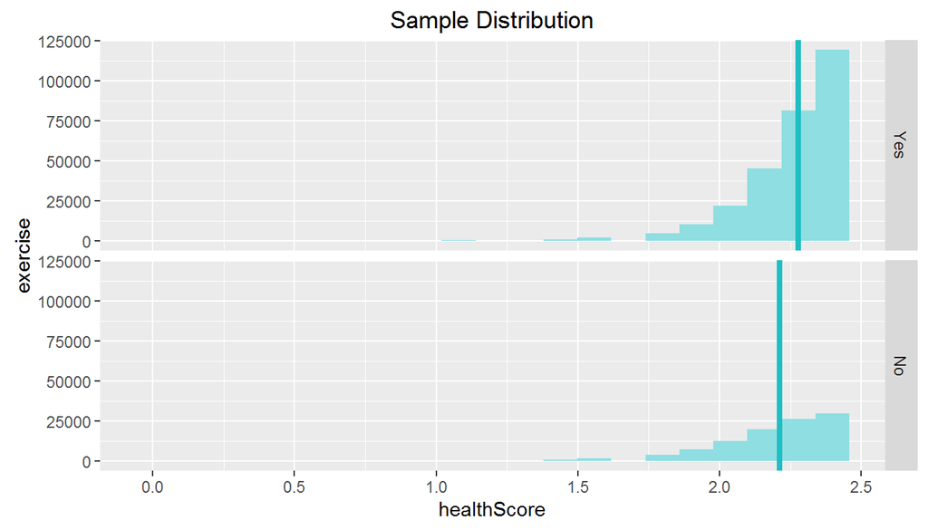

```r
# Hypothesis Test with functions (Mean : Catagorical vs Quantative)
inference(y = healthScore, x = exercise, data = data, statistic = "mean", type = "ht", null = 0,
          alternative = "twosided", method = "theoretical")
```

```
## Response variable: numerical
## Explanatory variable: categorical (2 levels)
## n_Yes = 286237, y_bar_Yes = 2.2787, s_Yes = 0.1596
## n_No = 103243, y_bar_No = 2.2109, s_No = 0.2143
## H0: mu_Yes =  mu_No
## HA: mu_Yes != mu_No
## t = 92.8452, df = 103242
## p_value = < 0.0001
```

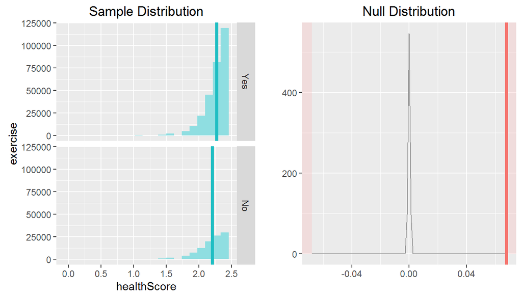

```r
s1 <- sd(data[data$exercise == "Yes", ]$healthScore)
s2 <- sd(data[data$exercise == "No", ]$healthScore)
n1 <- nrow(data[data$exercise == "Yes", ])
n2 <- nrow(data[data$exercise == "No", ])
x1 <- mean(data[data$exercise == "Yes", ]$healthScore)
x2 <- mean(data[data$exercise == "No", ]$healthScore)

# Confidence Interval with hand
x_diff <- x1 - x2
se <- sqrt((s1^2/n1) + (s2^2/n2))

z <- abs(qnorm(.025))  # 95%
ci <- round(c(x_diff - z*se, x_diff + z*se), 4)
ci
```

```
## [1] 0.0664 0.0693
```

```r
# Hypothesis Test with hand
se <- sqrt((s1^2/n1) + (s2^2/n2))
t <- (x1 - x2) / se
df <- min(n1, n2) - 1
1 - pt(t, df)
```

```
## [1] 0
```

**Interpretation**  
The population mean lies between these two bounds of 0.0664 0.0693, since 95% of the time confidence intervals contain the true mean.  
Since the p-value is less than .05 we will reject the null hypothesis and accept the alternative hypothesis that excersie hobit is effecting on Health Score.

### Smoking vs Exercise.

$H_0: \mu_{smoking} = \mu_{notSmoking}$; $H_A: \mu_{smoking} \ne \mu_{notSmoking}$

```r
# Confidence Interval with function (Proportion : Catagorical vs Catagorical)
inference(y = smoking, x = exercise, data = data, statistic = "proportion", type = "ci",
          method = "theoretical", success = "Yes")
```

```
## Response variable: categorical (2 levels, success: Yes)
## Explanatory variable: categorical (2 levels)
## n_Yes = 286237, p_hat_Yes = 0.4327
## n_No = 103243, p_hat_No = 0.5223
## 95% CI (Yes - No): (-0.0932 , -0.0861)
```

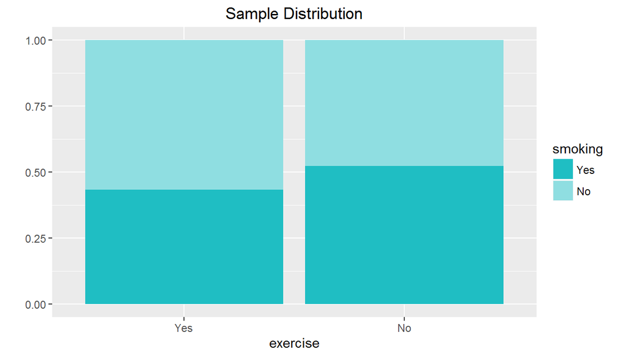

```r
# Hypothesis Test with functions (Proportion : Catagorical vs Catagorical)
inference(y = smoking, x = exercise, data = data, statistic = "proportion", type = "ht", null = 0,
          alternative = "twosided", method = "theoretical", success = "Yes")
```

```
## Response variable: categorical (2 levels, success: Yes)
## Explanatory variable: categorical (2 levels)
## n_Yes = 286237, p_hat_Yes = 0.4327
## n_No = 103243, p_hat_No = 0.5223
## H0: p_Yes =  p_No
## HA: p_Yes != p_No
## z = -49.5551
## p_value = < 0.0001
```

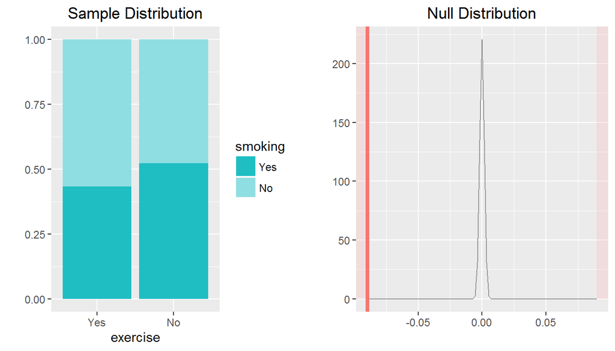

```r
n1 <- nrow(data[data$exercise == "Yes", ])
n2 <- nrow(data[data$exercise == "No", ])
p1 <- nrow(data[data$smoking == "Yes" & data$exercise == "Yes", ])/ n1
p2 <- nrow(data[data$smoking == "Yes" & data$exercise == "No", ])/ n2
se <- sqrt((p1*(1-p1)/n1) + (p2*(1-p2)/n2))

# Confidence Interval with hand
z <- abs(qnorm(.025))
p_dff <- abs(p1 - p2)
result <- round(c(p_dff - z*se, p_dff + z*se), 4)
result
```

```
## [1] 0.0861 0.0932
```

```r
# Hypothesis Test with hand
t <- (p1 - p2) / se
df <- min(n1, n2) - 1
(1 - pt(t, df))*2
```

```
## [1] 2
```

### Health Score vs Income Group.

$H_0: \mu_{1} = \mu_{2} = \mu_{3} ... = \mu_{k}$; $H_A:$ At least one mean is different

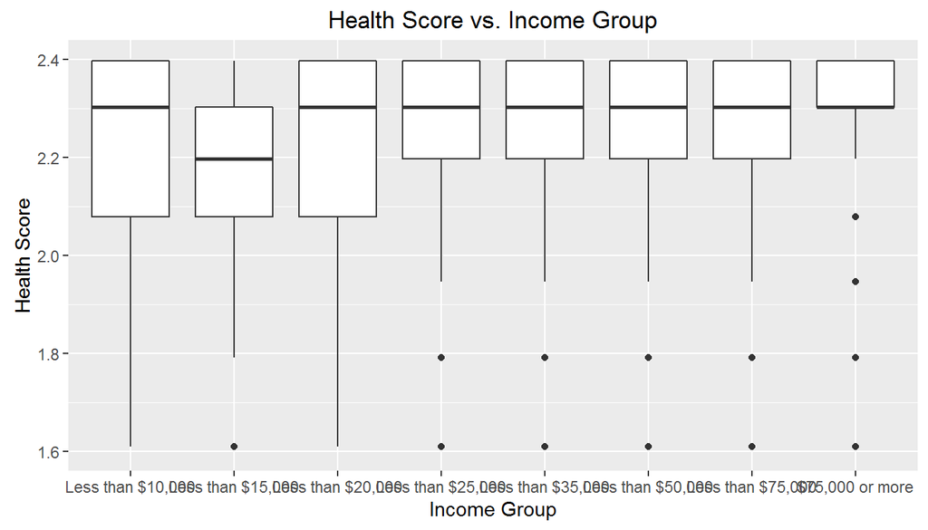

```r
# ANOVA with function (Proportion : Catagorical vs Multiple Catagorical)
model <- aov(healthScore ~ income, data = data)
ggplot(data, aes(income, healthScore)) +
     geom_boxplot() +
     ylim(1.6, 2.4) +
     labs(title = "Health Score vs. Income Group") +
     xlab("Income Group") +
     ylab("Health Score")
```

```r
anova(model)
```

```
## Analysis of Variance Table
##
## Response: healthScore
##               Df  Sum Sq Mean Sq F value    Pr(>F)
## income         7   824.2  117.75  3967.1 < 2.2e-16 ***
## Residuals 389472 11560.1    0.03
## ---
## Signif. codes:  0 '***' 0.001 '**' 0.01 '*' 0.05 '.' 0.1 ' ' 1
```

```r
result <- 824/(824+11560)
result
```

```
## [1] 0.06653747
```

```r
# We need to caluclate new p-value for ANOVA
k <- length(unique(data$income))
k <- k*(k-1)/2
alpha <- .05
alpha_adj <- alpha/k
alpha_adj
```

```
## [1] 0.001785714
```

**Interpretation**  
7% percent of data is explained by this anlysis else are not explained by this variables. May be other confound veriables analysis is needed.  
Even though adjust p-value is 0.00179, we still reject the null hypothesis because F value is 2e-16.  
Therefore we can conclude that there are at least two group means are significantly different from each other.

### Health Score vs Sleeping Hours .

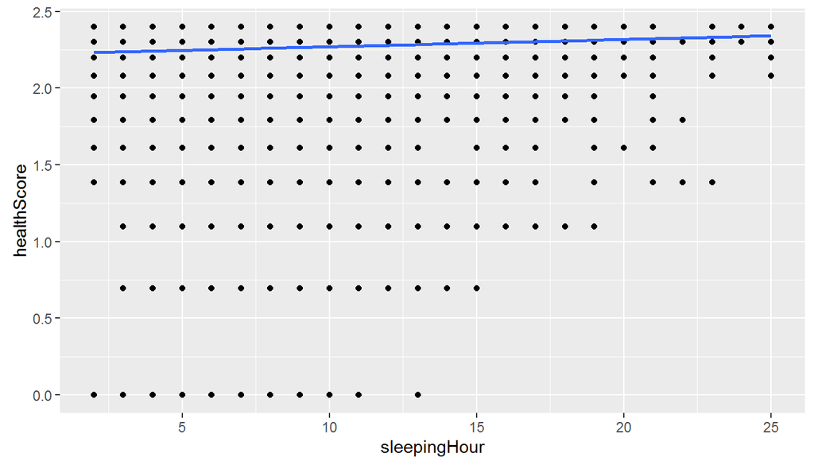

```r
data$sleepingHour <- as.numeric(data$sleepingHour)
p <- ggplot(data, aes(sleepingHour, healthScore)) +
     geom_point() +
     geom_smooth(method = "lm", se = FALSE)
p
```

**Interpretation**  
Although we do not see the strong relationship between sleeping hour and Health score, the liear regression line shows that there are slight effect going on. More sleeping hour refers better health condition in general.